# Project regresji i klasyfikacji

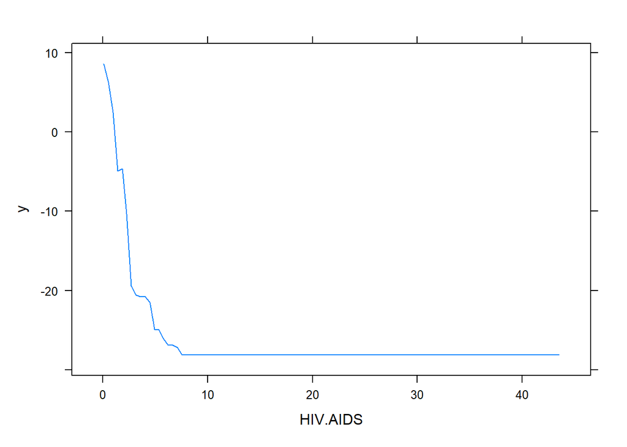

```r
plot(boost, i.var = "HIV.AIDS")
```

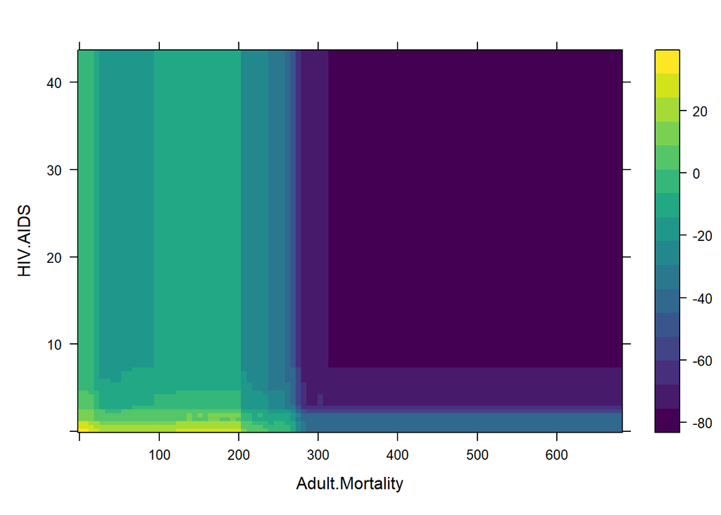

```r
plot(boost, i.var = c("Adult.Mortality", "HIV.AIDS"))
```

W celu wyznaczenia błędu testowego zbudowano model przy pomocy funkcji train, a metodą którą wykorzystano był gbm. Parametr spowalniający uczenie ustalono na 0.01.

```r
set.seed(1)
library(caret)
boost <- train(Long~.- (Life.expectancy + age_group + Status), data = newdataDecision[class_train,], distribution = "bernoulli",  method = 'gbm',  verbose = F, tuneGrid=data.frame(.n.trees=5000, .shrinkage=0.01, .interaction.depth=4, .n.minobsinnode=1))
boost
```

```
## Stochastic Gradient Boosting
##
## 193 samples
##  21 predictor
##   2 classes: '0', '1'
##
## No pre-processing
## Resampling: Bootstrapped (25 reps)
## Summary of sample sizes: 193, 193, 193, 193, 193, 193, ...
## Resampling results:
##
##   Accuracy   Kappa
##   0.8973949  0.7605812
##
## Tuning parameter 'n.trees' was held constant at a value of 5000
##
## Tuning parameter 'shrinkage' was held constant at a value of 0.01
##
## Tuning parameter 'n.minobsinnode' was held constant at a value of 1
```

Model trenuje się dłużej niż poprzednie. Obliczenia predykcji dały wynik:

```r
set.seed(1)
boost_pred <- predict(boost, newdata = newdataDecision[class_test,], n.trees = 5000)
table(boost_pred, Long[class_test])
```

```
##
## boost_pred   0   1
##          0  44   3
##          1  14 133
```

```r
boost_1 <-mean(boost_pred != Long[class_test])
boost_1
```

```
## [1] 0.08762887
```

### Dla regresji

Do celów regresji wykorzystano rozkład “gaussian”, liczba drzew wyniosła 5000, głębokość interakcji 4, a parametr spowalniający uczenie ustawiono na 0.01.

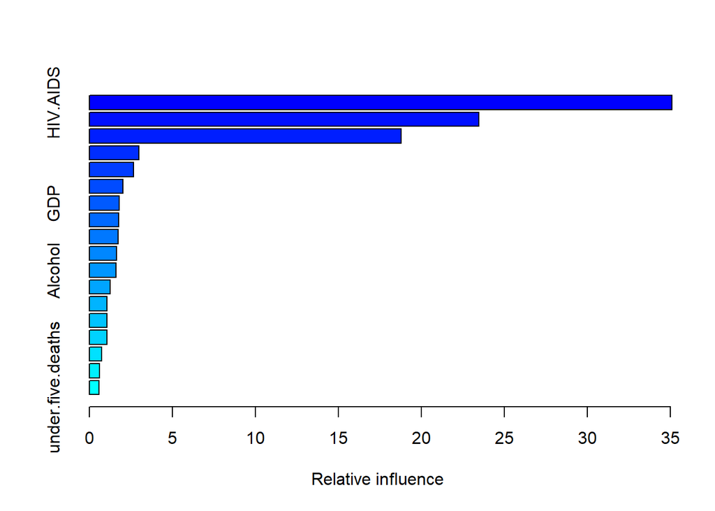

```
##                                                             var    rel.inf
## HIV.AIDS                                               HIV.AIDS 35.0977867
## Adult.Mortality                                 Adult.Mortality 23.4721688
## Income.composition.of.resources Income.composition.of.resources 18.7784439
## thinness.5.9.years                           thinness.5.9.years  2.9754188
## Schooling                                             Schooling  2.6767807
## thinness..1.19.years                       thinness..1.19.years  2.0243452
## GDP                                                         GDP  1.8132097
## BMI                                                         BMI  1.7663047
## percentage.expenditure                   percentage.expenditure  1.7468146
## Total.expenditure                             Total.expenditure  1.6343520
## Alcohol                                                 Alcohol  1.6085959
## Measles                                                 Measles  1.2655274
## Population                                           Population  1.0676952
## Diphtheria                                           Diphtheria  1.0668541
## infant.deaths                                     infant.deaths  1.0622675
## Polio                                                     Polio  0.7286863
## Hepatitis.B                                         Hepatitis.B  0.6215087
## under.five.deaths                             under.five.deaths  0.5932398
```

```r
set.seed(1)
boost2 <- gbm(Life.expectancy ~ . -(Status + age_group), data = newdata[reg_train,], distribution = "gaussian", n.trees = 5000, interaction.depth = 4, shrinkage = 0.01)
summary(boost2)
```

Najbardziej istotnymi predyktorami są HIV.AIDS, Adult.Mortality oraz Income.composition.of.resources.

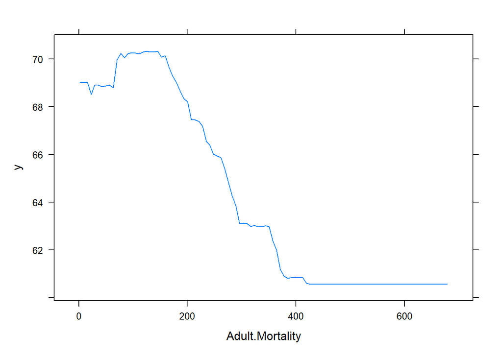

```r
plot(boost2, i.var = "Adult.Mortality")
```

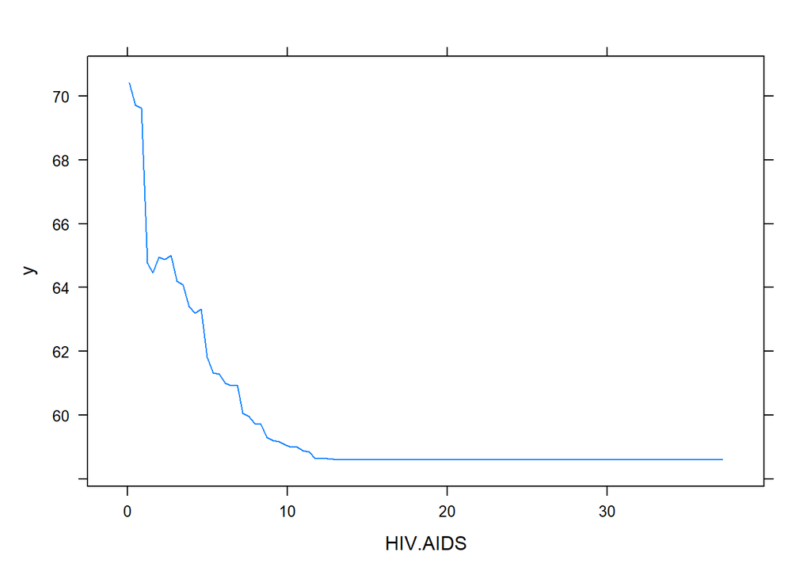

```r
plot(boost2, i.var = "HIV.AIDS")
```

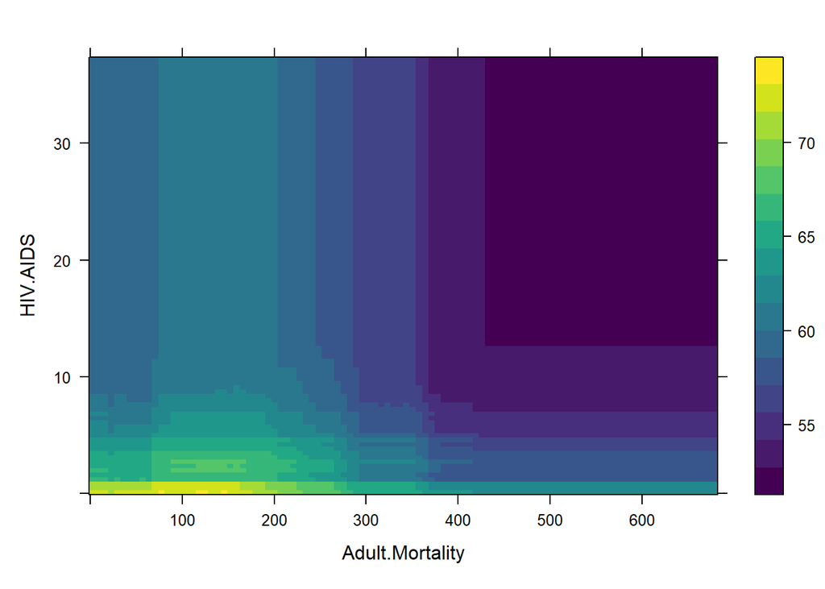

```r
plot(boost2, i.var = c("Adult.Mortality", "HIV.AIDS"))
```

Estymata błędu testowego na zbiorze walidacyjnym wyniosła:

```r
set.seed(1)
boost_pred2 <- predict(boost2, newdata = newdata[reg_test,], n.trees = 5000)
boost_2 <- mean((boost_pred2 - newdata$Life.expectancy[reg_test])^2)
boost_2
```

```
## [1] 9.040482
```

Porównanie wyników algorytmów: drzewa decyzyjnego, lasów losowych oraz boostingu dla problemu klasyfikacji:

```r
tab3 <- matrix(c(100 -tree_1*100, 100 -tree_2*100, 100 -forest_1*100, 100- boost_1*100), ncol=1, byrow=TRUE)
colnames(tab3) <- c("Skuteczność predykcji [%]")
rownames(tab3) <- c('Drzewo decyzyjne', 'Drzewo decyzyjne (size_opt)',  'Lasy losowe',  'Boosting')
tab3 <- as.table(tab3)
tab3
```

```
##                             Skuteczność predykcji [%]
## Drzewo decyzyjne                             89.69072
## Drzewo decyzyjne (size_opt)                  87.62887
## Lasy losowe                                  93.29897
## Boosting                                     91.23711
```

Porównanie wyników algorytmów: drzewa decyzyjnego, lasów losowych oraz boostingu dla problemu regresji:

```r
tab4 <- matrix(c( tree_3, tree_4, forest_2, boost_2), ncol=1, byrow=TRUE)
colnames(tab4) <- c("MSE")
rownames(tab4) <- c('Drzewo decyzyjne', 'Drzewo decyzyjne (size_opt)', 'Lasy losowe',  'Boosting')
tab4 <- as.table(tab4)
tab4
```

```
##                                   MSE
## Drzewo decyzyjne            16.736689
## Drzewo decyzyjne (size_opt) 16.736689
## Lasy losowe                  5.955499
## Boosting                     9.040482
```

Dla obu problemów najlepsze wyniki osiągnął algorytm lasów losowych, a najgorzej zwykłe drzewo decyzyjne. W przypadku klasyfikacji stworzenie modelu drzewa na podstawie optymalnej wartości parametru głębokości drzewa spowodowało pogorszenie wyników, podczas gdy najlepsza wartość tego parametru pokrywa się z modelem defaultowym.

## Podsumowanie

W powyższym projektcie dokonano szerokiej analizy problemu klasyfikacji oraz regresji dla zbioru dotyczącego oczekiwanej długości życia. Porównano różne metody klasyfikacji, selekcji cech oraz sprawdzono działanie modeli pokrewnych drzewom decyzyjnym. Wyniki zebrane w tabelach porównawczych jeszcze raz zaprezentowano poniżej.

### Porównanie wyników różnych metod klasyfikacji

```r
tab <- matrix(c(log$acc, log$acc2, lda$acc, lda$acc2, 0, knn$acc1, knn$acc3, knn$acc5, knn$acc7, knn$acc10), ncol=1, byrow=TRUE)
colnames(tab) <- c("Skuteczność [%]")
rownames(tab) <- c('Regresja Logistyczna 1', 'Regresja Logistyczna 2', 'LDA 1', 'LDA 2', 'Qda', 'kNN, k = 1', 'kNN, k = 3', 'kNN, k = 5', 'kNN, k = 7','kNN, k = 10')
tab <- as.table(tab)
tab
```

```
##                        Skuteczność [%]
## Regresja Logistyczna 1        84.61538
## Regresja Logistyczna 2        87.17949
## LDA 1                         85.89744
## LDA 2                         88.46154
## Qda                            0.00000
## kNN, k = 1                    47.43590
## kNN, k = 3                    58.97436
## kNN, k = 5                    60.25641
## kNN, k = 7                    67.94872
## kNN, k = 10                   61.53846
```

### Porównanie wyników różnych metod selekcji cech

```r
selection_tab <- matrix(c(selection$cpmin, selection$bicmin, selection$adjr2min, selection_fwd$cpmin, selection_fwd$bicmin, selection_fwd$adjr2min, selection_bwd$cpmin, selection_bwd$bicmin, selection_bwd$adjr2min, selection_v$best, selection_cross$best), nrow=11,ncol=1)
colnames(selection_tab) <- c("Ilość predyktorów")
rownames(selection_tab) <- c('Selekcja Cp', 'Selekcja BIC', 'Selekcja adjr2', 'Selekcja forward Cp', 'Selekcja forward BIC', 'Selekcja forward adjr2', 'Selekcja backward Cp', 'Selekcja backward BIC', 'Selekcja backward adjr2', 'Model walidacyjny', 'k-krotna walidacja krzyżowa')

selection_tab <- as.table(selection_tab)
selection_tab
```

```
##                             Ilość predyktorów
## Selekcja Cp                                11
## Selekcja BIC                                8
## Selekcja adjr2                             12
## Selekcja forward Cp                        13
## Selekcja forward BIC                        6
## Selekcja forward adjr2                     13
## Selekcja backward Cp                       11
## Selekcja backward BIC                       8
## Selekcja backward adjr2                    12
## Model walidacyjny                          13
## k-krotna walidacja krzyżowa                 8
```

### Porównanie wyników algorytmów: drzewa decyzyjnego, lasów losowych oraz boostingu dla problemu klasyfikacji:

```r
tab3 <- matrix(c(100 -tree_1*100, 100 -tree_2*100, 100 -forest_1*100, 100- boost_1*100), ncol=1, byrow=TRUE)
colnames(tab3) <- c("Skuteczność predykcji [%]")
rownames(tab3) <- c('Drzewo decyzyjne', 'Drzewo decyzyjne (size_opt)',  'Lasy losowe',  'Boosting')
tab3 <- as.table(tab3)
tab3
```

```
##                             Skuteczność predykcji [%]
## Drzewo decyzyjne                             89.69072
## Drzewo decyzyjne (size_opt)                  87.62887
## Lasy losowe                                  93.29897
## Boosting                                     91.23711
```

### Porównanie wyników algorytmów: drzewa decyzyjnego, lasów losowych oraz boostingu dla problemu regresji:

```r
tab4 <- matrix(c( tree_3, tree_4, forest_2, boost_2), ncol=1, byrow=TRUE)
colnames(tab4) <- c("MSE")
rownames(tab4) <- c('Drzewo decyzyjne', 'Drzewo decyzyjne (size_opt)', 'Lasy losowe',  'Boosting')
tab4 <- as.table(tab4)
tab4
```

```
##                                   MSE
## Drzewo decyzyjne            16.736689
## Drzewo decyzyjne (size_opt) 16.736689
## Lasy losowe                  5.955499
## Boosting                     9.040482
```